# Generalized least squares

- When there is non-zero correlation of the error (or non-constant variance), in certain cases we can successfully reduce this back to our normal regression framework with generalized least squares.
- Particularly, let's assume that the error takes a particular (but more general) form,

  \[ \begin{align} cov\left(\boldsymbol{\epsilon}\right) = \sigma^2 \boldsymbol{\Sigma} \end{align} \]

  for a *known structure matrix* for the error \( \boldsymbol{\Sigma} \) but perhaps an *unkown scale coefficient* \( \sigma^2 \).
- This describes a sittuation in which we have knowledge of the correlation and relative variance between the errors, but we don't know the absolute scale of the variation.
- Let us recall some properties of postive-semidefinite, symmetric matrices:
  1. Positive-semidefinite matrices (by definition) have all non-negative eigenvalues.
  2. Symmetric matrices (by the spectral theorem) must have a decomposition into an orthogonal eigenbasis, one for which each basis vector is a principle axis corresponding to one of the eigenvalue scales of growth or decay.
- All covariance matrices satisfy the above two properties by their construction. Therefore, it makes sense to say that \( \boldsymbol{\Sigma} \) has a well defined square root,

  \[ \begin{align} \sqrt{\boldsymbol{\Sigma}} \triangleq \mathbf{S} \end{align} \]

### Cholesky decomposition

- A simple choice of a square root is the **symmetric** square root,

  \[ \begin{align} \mathbf{S} &\triangleq \mathbf{E} \mathrm{diag}\left(\sqrt{\lambda_i}\right) \mathbf{E}^\mathrm{T} \\ &= \mathbf{E} \begin{pmatrix} \sqrt{\lambda_1} & 0 & 0 &\cdots & 0 \\ 0 & \sqrt{\lambda_2} & 0 &\cdots & 0 \\ 0 & 0 & \sqrt{\lambda_3} & \cdots & 0 \\ \vdots & \vdots & \ddots & \ddots & \vdots \\ 0 & \cdots & \cdots & \cdots & \sqrt{\lambda_n} \end{pmatrix} \mathbf{E}^\mathrm{T} \end{align} \]

  where \( \lambda_i \) are the non-negative eigenvalues, and \( \mathbf{E} \) are the associated eigenvectors, of \( \boldsymbol{\Sigma} \).
- By the orthogonality of the eigenvectors, it is easy to verify that \( \mathbf{S}^2 = \boldsymbol{\Sigma} \).
- However, for matrices, we can define the square root in several different ways with different properties. A special alternative type of square root is given by a Cholesky factorization…

### Cholesky decomposition continued…

- When \( \boldsymbol{\Sigma} \) is positive-definite (all strictly positive \( \lambda_i \)) there is a **unique** decompostition of \( \mathbf{\Sigma} \) as,

  \[ \begin{align} \boldsymbol{\Sigma} \triangleq \mathbf{L} \mathbf{L}^\mathrm{T} \end{align} \]

  such that \( \mathbf{L} \) is lower triangular, with positive entries on the diagonal.
- That is, the matrix \( \mathbf{L} \) is of the form,

  \[ \begin{align} \mathbf{L} = \begin{pmatrix} L_{11} & 0 & 0 &\cdots & 0 \\ L_{21} & L_{22} & 0 &\cdots & 0 \\ L_{31} & L_{31} & L_{33} & \cdots & 0 \\ \vdots & \vdots & \ddots & \ddots & \vdots \\ L_{n1} & \cdots & \cdots & \cdots & L_{nn} \end{pmatrix} \end{align} \]
- When we allow \( \lambda_i=0 \) for some \( i \), the decomposition **will not be unique** but will still exist.
- This is a weak generalization of the idea of a “square-root” where now we ask that \( \mathbf{S} \mathbf{S}^\mathrm{T} = \boldsymbol{\Sigma} \).
- Cholesky decompositions are extremely useful in many areas of mathematics, and especially for our case where the covariance matrix will be strictly positive-definite.
- Returning to the regression analysis, we suppose that

  \[ \begin{align} cov\left(\boldsymbol{\epsilon}\right) = \sigma^2 \boldsymbol{\Sigma} \end{align} \]
- We will write \( \boldsymbol{\Sigma} = \mathbf{S} \mathbf{S}^\mathrm{T} \) in a Cholesky decomposition.
- Then, considering our form for the signal

  \[ \begin{align} \mathbf{Y}& = \mathbf{X} \boldsymbol{\beta} + \boldsymbol{\epsilon}&\\ \Leftrightarrow \mathbf{S}^{-1} \mathbf{Y}& = \mathbf{S}^{-1}\mathbf{X} \boldsymbol{\beta} + \mathbf{S}^{-1}\boldsymbol{\epsilon}\\ \Leftrightarrow \mathbf{Y}' &= \mathbf{X}' \boldsymbol{\beta} + \boldsymbol{\epsilon}' \end{align} \]

  for \( \mathbf{Y}',\mathbf{X}', \boldsymbol{\epsilon}' \) as defined by the relationship above.
- **Exercise:** compute the mean of \( \boldsymbol{\epsilon}' \).
- **Answer:** this can be performed as usual, distributing the expectation through the non-random component,

  \[ \begin{align} \mathbb{E}\left[ \boldsymbol{\epsilon}' \right] &= \mathbb{E} \left[ \mathbf{S}^{-1}\boldsymbol{\epsilon}\right] \\ &= \mathbf{S}^{-1} \mathbb{E}\left[ \boldsymbol{\epsilon}\right] \\ &= 0 \end{align} \]
- **Exercise:** using the previous property, compute the covariance of \( \boldsymbol{\epsilon}' \).
- **Answer:** noting that \( \boldsymbol{\epsilon}' \) is mean zero, then we can compute,

  \[ \begin{align} cov\left(\boldsymbol{\epsilon}\right) &= \mathbb{E}\left[ \left(\boldsymbol{\epsilon}'\right) \left(\boldsymbol{\epsilon}'\right)^\mathrm{T}\right] \\ &=\mathbb{E}\left[\left(\mathbf{S}^{-1}\boldsymbol{\epsilon}\right)\left(\mathbf{S}^{-1}\boldsymbol{\epsilon}\right)^\mathrm{T}\right]\\ &=\mathbf{S}^{-1}\mathbb{E}\left[\boldsymbol{\epsilon}\boldsymbol{\epsilon}^\mathrm{T}\right] \mathbf{S}^{-\mathrm{T}}\\ &= \mathbf{S}^{-1} \sigma^2 \boldsymbol{\Sigma} \mathbf{S}^{-\mathrm{T}} \\ &= \sigma^2\mathbf{S}^{-1}\left(\mathbf{S} \mathbf{S}^\mathrm{T} \right) \mathbf{S}^{-\mathrm{T}} \\ &= \sigma^2 \mathbf{I} \end{align} \]
- **Q:** How might we use this analysis to transform the variables into something easier to work with? In particular, what variables might satisfy the assumptions of ordinary least squares?
- **A:** Supposing that we can compute the variables,

  \[ \begin{align} \mathbf{X}' &\triangleq \mathbf{S}^{-1} \mathbf{X} \\ \mathbf{Y}' &\triangleq \mathbf{S}^{-1} \mathbf{Y} \end{align} \]

  the regression of \( \mathbf{Y}' \) in terms of \( \mathbf{X}' \) satisfies our usual Gauss-Markov assumptions, for error \( \boldsymbol{\epsilon}' \) such that \( cov\left(\boldsymbol{\epsilon}\right) = \sigma^2 \mathbf{I} \).
- Because the assumptions of the Gauss-Markov theorem hold for the transformed variables, we can re-derive the least-squares solution minimizing the associated residual sum of squares error.
- Specifically, we can write,

  \[ \begin{align} \hat{\boldsymbol{\epsilon}}' &= \mathbf{Y}' - \hat{\mathbf{Y}}'\\ & =\mathbf{S}^{-1}\left(\mathbf{Y} - \mathbf{X} \hat{\boldsymbol{\beta}}'\right) \end{align} \]

  for some choice of \( \hat{\boldsymbol{\beta}}' \).
- This choice of \( \hat{\boldsymbol{\beta}}' \) should be the one that minimizes the equation,

  \[ \begin{align} \left(\hat{\boldsymbol{\epsilon}}'\right)^\mathrm{T}\left(\hat{\boldsymbol{\epsilon}}'\right) & = \left(\mathbf{Y} - \mathbf{X} \boldsymbol{\beta}\right)^\mathrm{T}\mathbf{S}^{-\mathrm{T}}\mathbf{S}^{-1}\left(\mathbf{Y} - \mathbf{X} \boldsymbol{\beta}\right)\\ &= \left(\mathbf{Y} - \mathbf{X} \boldsymbol{\beta}\right)^\mathrm{T}\boldsymbol{\Sigma}^{-1}\left(\mathbf{Y} - \mathbf{X} \boldsymbol{\beta}\right) \end{align} \]

  for all choices of \( \boldsymbol{\beta} \).
- By substitution for our usual solution for the minimizer, with \( \mathbf{X}' \) and \( \mathbf{Y}' \), we find

  \[ \begin{align} \hat{\boldsymbol{\beta}}' &\triangleq \left( \left(\mathbf{X}'\right)^\mathrm{T} \left(\mathbf{X}'\right)\right)^{-1}\left(\mathbf{X}'\right)^\mathrm{T} \mathbf{Y}'\\ &=\left(\mathbf{X}^\mathrm{T} \mathbf{S}^{-\mathrm{T}} \mathbf{S}^{-1} \mathbf{X}\right)^{-1}\mathbf{X}^\mathrm{T} \mathbf{S}^{-\mathrm{T}} \mathbf{S}^{-1}\mathbf{Y} \\ & =\left(\mathbf{X}^\mathrm{T} \boldsymbol{\Sigma}^{-1} \mathbf{X}\right)^{-1}\mathbf{X}^\mathrm{T} \boldsymbol{\Sigma}^{-1}\mathbf{Y} \end{align} \]

  where hereafter, we will drop the \( ' \) from the \( \hat{\boldsymbol{\beta}}' \).
- **Q:** how can we compute \( cov\left(\hat{\boldsymbol{\beta}}\right) \)
- **Answer:** knowing that the regression of \( \mathbf{Y}' \) in terms of \( \mathbf{X}' \) satisfies the hypotheses of ordinary least squares, the simple method is substitution. I.e.,

  \[ \begin{align} cov\left(\hat{\boldsymbol{\beta}}\right) &= \left(\left(\mathbf{X}'\right)^\mathrm{T} \left(\mathbf{X}'\right)\right)^{-1} \sigma^2\\ &=\left(\mathbf{X} \mathbf{S}^{-\mathrm{T}} \mathbf{S}^{-1} \mathbf{X}\right)^{-1} \sigma^2\\ &= \left(\mathbf{X}^\mathrm{T} \boldsymbol{\Sigma}^{-1} \mathbf{X} \right)^{-1} \sigma^2 \end{align} \]
- **Q:** knowing that the error \( \boldsymbol{\epsilon}' = \mathbf{S}^{-1} \boldsymbol{\epsilon} \), how might this affect the usual diagnostics?
- **A:** We should consider, the residuals should likewise be transformed along with the other variables to give,

  \[ \begin{align} \hat{\boldsymbol{\epsilon}}'&\triangleq \mathbf{S}^{-1} \hat{\boldsymbol{\epsilon}}; \end{align} \]

  the residuals \( \hat{\boldsymbol{\epsilon}}' \) will be of the same form (iid/ constant variance) when \( \boldsymbol{\Sigma} \) is chosen correctly, such that our normal diagnostics applied to \( \hat{\boldsymbol{\epsilon}}' \) will remain the same.
- However, the issue is typically that \( \boldsymbol{\Sigma} \) is unkown in practice, except in special cases, and typically must be estimated.
- As noted before, the correlation structure will have much to do with the problem at hand, e.g.,
1. spatial correlations in spatial data;
2. auto-correlations in time series data;
3. batch correlations in batch collected data.

## Weighted least squares

- As a special case of generalized least squares, we can consider the case when the errors are uncorrelated, but have unequal variances.
- That is to say, \( cov\left(\boldsymbol{\epsilon}\right) = \boldsymbol{\Sigma} \) where,

  \[ \boldsymbol{\Sigma} = \begin{pmatrix} 1/w_1& 0 & \cdots & 0 \\ 0 & 1/w_2 & \cdots & \vdots \\ \vdots & \ddots & \ddots & \vdots \\ 0 & 0 & \cdots & 1/w_n \end{pmatrix} \] for possibly \( w_i \neq w_j \), but \( \boldsymbol{\Sigma} \) is strictly diagonal.
- Here, we will refer to the reciprocals of the individual variances, \( w_i \), as the **weights**.

**Exercise:** In this case, what is the square root of \( \boldsymbol{\Sigma} \)?

**A:** in this case, we can compute the square root identically by the component-wise square root, as diagonal matrices are a special class of matrices that are already in eigen-decomposition,

\[ \mathbf{S} = \begin{pmatrix} 1/\sqrt{w_1}& 0 & \cdots & 0 \\ 0 & 1/\sqrt{w_2} & \cdots & \vdots \\ \vdots & \ddots & \ddots & \vdots \\ 0 & 0 & \cdots & 1/\sqrt{w_n} \end{pmatrix} \]

- As a special case of generalized least squares, we can compute the transformation into the variables \( \mathbf{X}', \mathbf{Y}', \boldsymbol{\epsilon}' \) as

  \[ \begin{align} \mathbf{X}' &\triangleq \mathbf{S}^{-1} \mathbf{X} = \mathrm{diag}\left(\sqrt{w_i} \right)\mathbf{X}, \\ \mathbf{Y}' & \triangleq \mathbf{S}^{-1} \mathbf{Y} = \mathrm{diag}\left(\sqrt{w_i} \right) \mathbf{Y}, \\ \boldsymbol{\epsilon}' & \triangleq \mathbf{S}^{-1} \boldsymbol{\epsilon} = \mathrm{diag}\left(\sqrt{w_i} \right)\boldsymbol{\epsilon}; \end{align} \]
  - By direct matrix computation, we see that the **\( i \)-th row** of the matrix \( \mathbf{X} \) is scaled by the inverse of the standard deviation of the \( i \)-th observation.
- We note, the column corresponding to the intercept term in the matrix \( \mathbf{X} \) will be a vector of the form,

  \[ \begin{align} \begin{pmatrix} \sqrt{w_1}, &\cdots, & \sqrt{w_n}\end{pmatrix}^\mathrm{T}, \end{align} \] instead of the usual vector of ones.
- Qualitatively, we can note that
  1. the observations of high variance

     \[ \begin{align} \frac{1}{\sqrt{w_i}} \gg 1 \end{align} \]

     will recieve low weight in the regression \( \sqrt{w_i} \ll 1 \), while
  2. the observations of low variance

     \[ \begin{align} \frac{1}{\sqrt{w_i}} \ll 1 \end{align} \]

     will recieve high weight in the regression \( \sqrt{w_i} \gg 1 \)
- We will examine how the re-weighting of the least-squares fit affects the outcome in an example…

## An example of weighted least squares

[figure not shown]

Claude Monet, Rue Montorgueil,  
Paris, Festival of June 30, 1878.  
Public Domain.

- France follows run-off elections in which the leading two candidates in the first election will be voted on once again to decide a final outcome.
- The intention of this election style is to allow voters to pick a “second-choice” candidate, if their first choice wasn’t successful in the first round.
- In 1981 there were 10 candidates in the first round which was narrowed down to François Mitterand and Valéry Giscard-d’Estaing, who held the two highest vote totals in the first round.

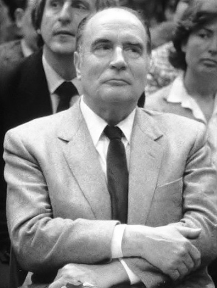

  Courtesy of Philippe Roos [CC 2.0](https://creativecommons.org/licenses/by-sa/2.0)

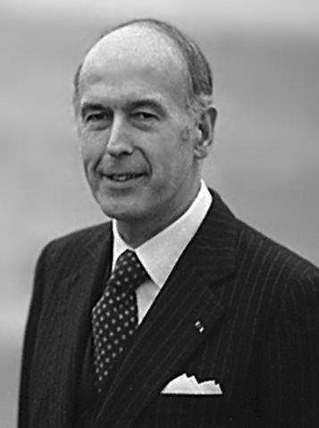

  Courtesy of White House Staff Photographers. Public domain.
- This kind of voting is the subject to poltical coalition building in which candidates who are elminated in the first round can encourage their supporters to vote for one of the final round candidates.
- However, the voting is done privately and anonymously, and voters don’t have to follow the advice of their first round pick.
- We will try to infer, based on published vote totals, how votes were transferred between candidates.
- In the the dataset “fpe” we find the published vote totals in every fourth department for France.

```r
library("faraway")
head(fpe)
```

```
                    EI   A   B   C   D  E  F  G  H  J K  A2  B2  N
Ain                260  51  64  36  23  9  5  4  4  3 3 105 114 17
Alpes               75  14  17   9   9  3  1  2  1  1 1  32  31  5
Ariege             107  27  18  13  17  2  2  2  1  1 1  57  33  6
Bouches.du.Rhone  1036 191 204 119 205 29 13 13 10 10 6 466 364 30
Charente.Maritime  367  71  76  47  37  8 34  5  4  4 2 163 142 17
Cotes.du.Nord      396  93  90  57  54 13  5  9  4  3 5 193 155 15
```

- The variables “A” and “B” correspond to the vote totals for Mitterand and Giscard in the first round, respectively.
  - The variables “A2” and “B2” correspond to their second round vote totals.
- The variable “EI” is the number of registered votes, and all numbers are measured in thousands.
- The difference between the number of voters in the second round and the first is given by the variable “N”.
  - In this case, we will treat this as any other explanatory variable, though it could be treated differently in principle.
- The varible that we will model for the response is “A2”, the number of second round votes given to Mitterand.
- Suppose we can write the signal an **exact** equation

  \[ \begin{align} A_2 = \beta_A A+ \beta_B B+\beta_C C+\beta_D D+\beta_E E+\beta_F F+\beta_G G+\beta_H H+\beta_J J+\beta_K K+\beta_N N \end{align} \] where each \( \beta_i \) represents the **true parameters**, giving the proportion of votes transferred to Mitterand in the second round from the country-wide totals.
- This is different from the regression equation, defined by

  \[ \begin{align} y_i = \mathbf{x}_i^\mathrm{T} \boldsymbol{\beta} + \epsilon_i, \end{align} \]

  where for some choice of explanatory variables \( \mathbf{x}_i \) (the vote totals of a particular department) the will be missmatch (\( \epsilon_i \)) between the proportion of votes transferred from the overall totals (\( \beta_i \)) and the local totals.
- The error term will likely have different variance with respect to different departments;
  - Assuming (naively) that the total votes for Mitterand in the second round for a particular district is the sum of uncorrelated random variables (the first round candidate totals for a particular department), then
  - we might treat the variance of the second round outcome for Mitterand in a district as proportional to the number of voters in the district;
  - this is because the variance of the left side of the equation (\( y_i \)) will be equal to a weighted sum of the variances of the right side (\( x_i \)).
- If the weights for each department are to be inversely proportional to their variance, we may set the weights equal to 1/EI.
- Note, it is natural in this equation to neglect the intercept, as there should be no vote transfer when there are no voters.

```r
lmod <- lm(A2 ~ A+B+C+D+E+F+G+H+J+K+N-1, fpe, weights=1/EI)
coef(lmod)
```

```
         A          B          C          D          E          F
 1.0671302 -0.1050507  0.2459577  0.9261878  0.2493970  0.7551100
         G          H          J          K          N
 1.9722124 -0.5662165  0.6116417  1.2106584  0.5293527
```

- Fitting the model without weights, we find a substantial difference,

```r
lm(A2 ~ A+B+C+D+E+F+G+H+J+K+N-1, fpe)$coef
```

```
         A          B          C          D          E          F
 1.0751478 -0.1245589  0.2574465  0.9045371  0.6706768  0.7825333
         G          H          J          K          N
 2.1656554 -0.8542876  0.1444185  0.5181332  0.5582718
```

- However, there is an issue about the physicallity of the model, where proportions should be between zero and one.
- To fix this, we can logically remove the voters for Giscard and likewise automatically set the vote transfer for Mitterand to one (assuming that each block votes once again for the same candidate in the second round).
- As an ad hoc fix for the other parameters greater than one, we set these to one exactly (along with the parameter for Mitterand) with the “offset” function;
- Likewise, for the other coefficients that are negative, we set these to zero (removing them from the regression equation):

```r
lmod <- lm(A2 ~ offset(A+G+K)+C+D+E+F+N-1, fpe, weights=1/EI)
coef(lmod)
```

```
        C         D         E         F         N
0.2257726 0.9699765 0.3902044 0.7442401 0.6085392
```

- The above coefficients suggest (roughly true to historical understanding) that:
1. Nearly all communist party voters (D) supported Mitterand in the second round;
2. Surprisingly, a signficant number \( \approx 20\% \) of Gaullist voters ( C ) voted for Mitterand, shifting the overall balance;
3. Ecology party voters (E) split their votes almost evenly in the second round;
4. Non-voters in the first round split their vote rougly evenly.
- We note, the analysis we had on the French 1981 presidential performed more rigorously with a form of constrained least squares;
  - That is, using a more sophisticated package, we can explicitly set the range for the parameters \( 0 \leq \hat{\boldsymbol{\beta}}_i \leq 1 \).
  - This is discussed explicitly in the book.
- In examples where the variances are unknown, we may consider an ansatz for the form of the **dependence** of the variance on the observation.
- Let's consider data on the stopping distance of cars with respect to the observed speed.

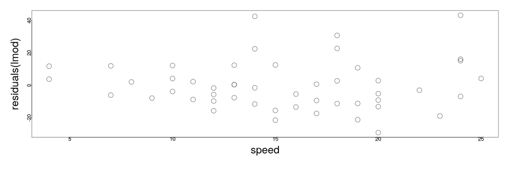

```r
par(mai=c(1.5,1.5,.5,.5), mgp=c(3,0,0))
lmod <- lm(dist ~ speed, cars)
plot(residuals(lmod) ~ speed, cars,  cex=3, cex.lab=3, cex.axis=1.5)
```

- Plotting the residuals versus the fitted values, we see what appears to be increasing variance with respect to the increasing speed.
- As an ansatz, we may consider a dependence relationship as,

  \[ \begin{align} \mathrm{sd}(\boldsymbol{\epsilon}_i )= \gamma_0 + x_i^{\gamma_1} \end{align} \]
- These coefficients, representing an exponential increase in the standard deviation with the speed of the vehicle, can be estimated simultaneously with the parameters for the regression.
- Here, we will use the generalized least squares function “gls” in the “mgcv” library, with a function in the argument for the weights.

```r
library("mgcv")
wlmod <- gls(dist ~ speed, data=cars, weight = varConstPower(1, form= ~ speed))
```

```r
summary(wlmod)
```

```
Generalized least squares fit by REML
  Model: dist ~ speed
  Data: cars
       AIC      BIC    logLik
  412.8352 422.1912 -201.4176

Variance function:
 Structure: Constant plus power of variance covariate
 Formula: ~speed
 Parameter estimates:
   const    power
3.160444 1.022368

Coefficients:
                 Value Std.Error   t-value p-value
(Intercept) -11.085378  4.052378 -2.735524  0.0087
speed         3.484162  0.320237 10.879947  0.0000

 Correlation:
      (Intr)
speed -0.9

Standardized residuals:
       Min         Q1        Med         Q3        Max
-1.4520579 -0.6898209 -0.1308277  0.6375029  3.0757014

Residual standard error: 0.7636833
Degrees of freedom: 50 total; 48 residual
```

```r
summary(lm(dist ~ speed, data=cars))
```

```
Call:
lm(formula = dist ~ speed, data = cars)

Residuals:
    Min      1Q  Median      3Q     Max
-29.069  -9.525  -2.272   9.215  43.201

Coefficients:
            Estimate Std. Error t value Pr(>|t|)
(Intercept) -17.5791     6.7584  -2.601   0.0123 *
speed         3.9324     0.4155   9.464 1.49e-12 ***
---
Signif. codes:  0 '***' 0.001 '**' 0.01 '*' 0.05 '.' 0.1 ' ' 1

Residual standard error: 15.38 on 48 degrees of freedom
Multiple R-squared:  0.6511,    Adjusted R-squared:  0.6438
F-statistic: 89.57 on 1 and 48 DF,  p-value: 1.49e-12
```

- Compared to the weighted least squares formulation, with the exponential increase in variance, we have a significantly poorer fit.
  - This is evidenced in terms of the drastic difference in the residual standard error for each model:
  1. weighted \( \approx 0.76 \)
  2. ordinary \( \approx 15.38 \)

## Testing for lack of fit

- When our assumptions (e.g., G-M) hold then the residual standard error,

  \[ \begin{align} \hat{\sigma}^2 \triangleq \frac{\hat{\epsilon}^\mathrm{T} \hat{\epsilon}}{n-p} \end{align} \]

  is an unbiased estimate of the true variance \( \sigma^2 \) of the error.
- However, we have now seen many ways how these assumptions can break down.
  - When the model doesn't have the appropriate structure or is not complex enough to fit the data, we will typically overestimate \( \sigma^2 \) with the emprical \( \hat{\sigma}^2 \);
  - likewise, if we over parameterize the model, then \( \hat{\sigma}^2 \) will typically underestimate the true variance \( \sigma^2 \).
- In an ideal sittuation, where we may actually know \( \sigma^2 \), comparing the two values would lead us to understanding the fit of the model by our empirical estimate versus the known value.
  - One example may be when we have only measurement errors for the observations with known variance in their measurments.
- By the same principle, we may more generally get a good estimate of \( \sigma^2 \) when we have multiple observations of the response for the same values of the explanatory variables…